# C06

Previous: Lecture 5 Array and String , next: Lecture 7 Function

Lecture 6 For Loop structure

#### CSCI218 Engineering Programming (by Kebin Xu)

1. for loop
   - ++i vs i++
   - loop through arrary
     - examples and exercise
   - Using loop to update certain variable
2. break and continue
3. 2D array and nested for loop
   - Example
4. accumulating pattern
   - summation and product
   - generating sequence
   - FRACTIONAL PATTERNS
   - Fiboancci sequence

## 1. for loop

- A type of loop in which the number of times the statements in a loop run is numerically defined.
- It used to execute a set of programming statements multiple times

[figure not shown]

- The for loop statement itself has three parts. Each places a role in setting up and running a logical test that determines how many times the statements are executed.
  - initial condition,
  - the test,
  - the increment.

Eventually the programming statements in increment will create a situation where the test no lon- ger evaluates to true. When this happens, the programming statements within the curly braces are no longer executed, and the program will move to what comes after the for loop.

```c
#include <stdio.h>
int main(){
    int i; //loop index
    for (i = 0;i < 5; i++){ // i = i + 1; i += 1; i++, ++i
        printf("i = %d\n", i);
    }
    return 0;
}
```

```
i = 0
i = 1
i = 2
i = 3
i = 4
```

#### A `for` loop executes the

1. **initialization** loop variable, i = 0 , only once; at the very beginning of the statement.
2. **check the loop's condition**, i < 5, before each time through the loop,
   - if the condition is true, everything in the loop body will execute (everything between the curly braces)
   - if the conditon is false,we will exit the loop
3. After we execute what's in the loop body (given the condition evaluated to true), **update loop variable** : i ++, then go to step 2

#### In the above code, the increment part: i = i + 1 and i += 1 and i++ and ++1 are equivalent.

## 1.1 i++ vs ++i

- Two types of increment operators(++)
  - ++i //pre-increment
  - i++ //post-increment
- ++i and i++ increment i by 1, they are equivalent
- They acts differently in assignment
  - y = i++; //post-increment , assgin i to y, then increment i by 1
  - y = ++i; //pre-increment, increment i by 1 first , then assgin the updated i to y
- Two types of decrement operators(--)
  - the same as ++

```c
#include <stdio.h>
int main(){
    int i = 5;
    int y ;
    y = i++;
    printf("y = i++ (post-increment ): y = %d, i = %d\n", y, i ); //post-increment
    i = 5;
    y = ++i;
    printf("y = ++i (pre-increment ): y = %d, i = %d\n", y, i ); //pre-increment
}
```

```
y = i++ (post-increment ): y = 5, i = 6
y = ++i (pre-increment ): y = 6, i = 6
```

```c
//backward using i--
#include <stdio.h>
int main(){
    int i; //loop index
    for (i = 4;i >= 0; i--){ // i = i - 1; i -= 1; i--, --i
        printf("i = %d\n", i);
    }
    return 0;
}
```

```
i = 4
i = 3
i = 2
i = 1
i = 0
```

### Example

**E1.1_Q1** turn on 7 LEDs one by one with some interval seconds as you like in between, then turn off the LEDs one by one in reverse order.

```c
const int INTERVAL = 500;
// the setup function runs once when you press reset or power the board
void setup() {

    Serial.begin(9600);
    // initialize digital pin 4 to 10 as output
    for(int i = 4; i<= 10; i++){
        pinMode(i, OUTPUT);
        digitalWrite(i, LOW);   //set all lights off when program starts
    }
}

// the loop function runs over and over again forever
void loop() {
    int i;

    // turn on the LEDs one by one with 1000/INTERVAL Hz frequency
    for (i = 4; i <= 10; i++){
        digitalWrite(i, HIGH);
        Serial.println(i);
        delay(INTERVAL);
    }

    delay (INTERVAL);

    // turn off the LED one by one with 1000/INTERVAL Hz frequency
    for (i = 10; i >= 4; i--){
        digitalWrite(i, LOW);
        Serial.println(i);
        delay(INTERVAL);
    }

}
```

back to top

## 1.2 loop through arrary

### Examples

- **E1.2_Q1**: Count how many negative numbers exist in the array.

```c
//Example E1.2_Q1
#include <stdio.h>
int main(){
    int nums[] = { 3, -2, 1, -1, 8, 9, -4};
    int cntNeg = 0;
    int N_SIZE = sizeof(nums)/sizeof(int);
    int i;
    for (i = 0; i < N_SIZE; ++i) {
       if ( nums[i] < 0 ) {
          ++cntNeg; // cnNeg++
       }
    }
    printf("There are %d negatives in the array", cntNeg);

    return 0;
}
```

```
There are 3 negatives in the array
```

```c
//Example E1.2_Q2
#include <stdio.h>
int main(){
    int nums[] = { 3, -2, 1, -1, 8, 9, -4};
    int count = 0;
    int N_SIZE = sizeof(nums)/sizeof(int);
    int i;
    for (i = 0; i < N_SIZE; ++i) {
       if ( nums[i] % 2 == 1 ||  nums[i] % 2 == -1) {  //or better using if(nums[i] % 2)
          ++count; // count++
       }
    }
    printf("There are %d odd in the array", count);

    return 0;
}
```

```
There are 4 odd in the array
```

```c
//Example E1.2_Q3
#include <stdio.h>
int main(){
    int nums[] = { 3, -2, 1, -1, 8, 9, -4};
    int count = 0;
    int N_SIZE = sizeof(nums)/sizeof(int);
    int i;
    for (i = 0; i < N_SIZE; ++i) {
       if ( nums[i] > 2 ) {
          ++count; // count++
       }
    }
    printf("There are %d number greater than 2  in the array", count);

    return 0;
}
```

```
There are 3 number greater than 2  in the array
```

**E1.2_Q4**: Modifying an array in a loop: Converting negatives to 0.

```c
#include <stdio.h>
int main(){
    int myVals[] = { 3, -2, 1, -1, 8, 9, -4};
    int N_SIZE = sizeof(myVals)/sizeof(int);
    int i;

    printf("\nAfter modifying, myVals[] = {");
    for (i = 0; i < N_SIZE; ++i) {
        if (myVals[i] < 0)
            myVals[i] = 0;
        //for the printing format purpose
        printf("%d", myVals[i]);
        if (i < N_SIZE -1 )
            printf(", ");
    }
    printf("}");

    return 0;
}
```

```
After modifying, myVals[] = {3, 0, 1, 0, 8, 9, 0}
```

## 1.3 Using loop to update certain variable

**E1.2_Q5**: find minimum number in an array, how about maximum?

```c
#include <stdio.h>
int main(){
    int myVals[] = { 3, -2, 1, -1, 8, 9, -4};
    int minVal = myVals[0];
    int N_SIZE = sizeof(myVals)/sizeof(int);
    int i;
    for (i = 0; i < N_SIZE; ++i) {
       if (myVals[i] < minVal) {
          minVal = myVals[i];  //updating minVal if we find a smaller number
       }
    }
    printf("The minimum of the array is %d", minVal);

    return 0;
}
```

```
The minimum of the array is -4
```

back to top

## 2. break and continue statements

Two jump statements alter the normal execution of a loop.

- The **break** statement breaks out of a loop prematurely.
- The **continue** statement causes a loop to iterate again without executing the remaining statements in the loop

### break

```c
#include <stdio.h>
int main(){
    int i;
    for (i = 1; i <= 5; i++) {
        if (i == 4) {
        break;   // Leave the loop
        }
        printf("%d ", i);   // 1 2 3 (missing 4 and 5)
    }
    return 0;
}
```

```
1 2 3
```

```c
#include <stdio.h>
int main(){
    int i;
    for (i = 1; i <= 5; i++) {
         printf("%d ", i);   //
        if (i == 4) {
        break;   // Leave the loop
        }

    }
    return 0;
}
```

```
1 2 3 4
```

**E3_Q1**: Write a program to test a given string a valid string or not. (a valid string can only have alphabet and digit).

```c
#include <stdio.h>
#include <string.h>
#include <ctype.h>
int main(){
    char text[100] = "9dogs"; //"a dog"
    int i;

    for (i = 0;i < strlen(text); i++){
        if (!isalnum(text[i] )){
            printf("invalid string.");
            break;
        }
    }
    if (i == strlen(text))
        printf("valid string.");

    return 0;
}
```

```
valid string.
```

```c
// using return
#include <stdio.h>
#include <string.h>
#include <ctype.h>
int main(){
    char text[100] = "9dogs"; //"a dog"
    int i;

    for (i = 0;i < strlen(text); i++){
        if (!isalnum(text[i] )){
            printf("invalid string.");
            return 0;
        }
    }

    printf("valid string.");

    return 0;
}
```

[output not shown]

**E3_Q2**: scan and count alphabets of a valid string(a valid string can only have alphabet and digit), display "invalid string" for invalid case.

```c
#include <stdio.h>
#include <string.h>
#include <ctype.h>
int main(){
    char text[100] = "9dogs!"; //"a dog"
    int i, counter = 0;

    for (i = 0;i < strlen(text); i++){
        if (isalnum(text[i] )){
            if(isalpha(text[i]))
                counter = counter + 1;
        }
        else {
            printf("invalid string\n");
            counter = 0;
            break;
        }
    }
    if (counter != 0)
        printf("%d", counter);
    return 0;
}
```

```
invalid string
```

```c
//Using return
#include <stdio.h>
#include <string.h>
#include <ctype.h>
int main(){
    char text[100] = "9dogs!"; //"a dog"
    int i, counter = 0;

    for (i = 0;i < strlen(text); i++){
        if (isalnum(text[i] )){
            if(isalpha(text[i]))
                counter = counter + 1;
        }
        else {
            printf("invalid string\n");
            return 0;
        }
    }

    printf("%d", counter);
    return 0;
}
```

```
invalid string
```

### continute

```c
#include <stdio.h>
int main(){
    int i;
    for (i = 1; i <= 5; i++) {
        if (i == 4 || i == 2){
            continue; //skip the rest statement of for statement
        }
        printf("%d ", i);   // 1  3 (missing 4)  5
    }
    return 0;
}
```

```
1 3 5
```

back to top

## 3. 2D array and nested for loop

An array of arrays is known as 2D array. The two dimensional (2D) array in C programming is also known as matrix. A matrix can be represented as a table of rows and columns.

### 3.1 Initialization of 2D Array

There are two ways to initialize a two Dimensional arrays during declaration.

```
int table[2][3] = {
        {10, 20, 30},
        {40, 50, 60}
    };
```

or

```
int table[2][3] = { 10, 20, 30, 40, 50, 60};
```

Although both the above declarations are valid, I recommend you to use the first method as it is more readable, because you can visualize the rows and columns of 2d array in this method.

```c
//Ex1
#include <stdio.h>
int main()
{
    int table[][3] = { 10, 20, 30, 40, 50, 60};
    printf("table[1][2] = %d\n", table[1][2]);
    int anotherTable[3][2] = { 10, 20, 30, 40, 50, 60};
     printf("\nanotherTable[0][1] = %d", anotherTable[0][1]);
    return 0;
}
```

```
table[1][2] = 60

anotherTable[0][1] = 20
```

#### Things that you must consider while initializing a 2D array

We already know, when we initialize a normal array (or you can say one dimensional array) during declaration, we need not to specify the size of it. However that’s not the case with 2D array, you must always specify the second dimension even if you are specifying elements during the declaration. Let’s understand this with the help of few examples –

```c
/* Valid declaration*/
int abc[2][3] = {1, 2, 3 ,4 }
/* Valid declaration*/
int abc[][4] = {1, 2, 3 ,4 }
/* Invalid declaration – you must specify second dimension*/
int abc[][] = {1, 2, 3 ,4 }
/* Invalid because of the same reason  mentioned above*/
int abc[2][] = {1, 2, 3 ,4 }
```

### 3.2 Example

```c
#include <stdio.h>
int main() {
    /* a table of 4x3 */
    int abc[][4] = {1, 2, 3 ,4 } ;
    printf("abc[0][3]:%d \n", abc[0][3]);

    int nums[4][3] = {1,2,3,4,5,6,7,8,9,10,11,12};
    printf("nums[1][0]:%d \n",nums[2][0] );
    int i;

    printf("all numbers in the second row:\n");
    for (i= 0; i <3; i++)
        printf("nums[1][i]= %d ", nums[1][i]);

    printf("\n\nall numbers in the first column:\n");
    for (i= 0; i <4; i++)
        printf("nums[i][0]= %d ", nums[i][1]);

    return 0;
}
```

```
abc[0][3]:4
nums[1][0]:7
all numbers in the second row:
nums[1][i]= 4 nums[1][i]= 5 nums[1][i]= 6

all numbers in the first column:
nums[i][0]= 2 nums[i][0]= 5 nums[i][0]= 8 nums[i][0]= 11
```

**E3_Q2**:Display 2D array (a table of numbers)

```c
#include <stdio.h>
int main() {
    /* a table of 4x3 */
    int nums[4][3] = {1,2,3,4,5,6,7,8,9,10,11,12};
    int i, j;

    for (i= 0; i< 4; i++){ //for row
        for(j = 0; j < 3; j++) // for column
        {
            printf("%d \t", nums[i][j]);
        }
        printf("\n");
    }

    return 0;
}
```

```
1 	2 	3
4 	5 	6
7 	8 	9
10 	11 	12
```

**E3_Q3**: using 2D array to store strings, use a for loop to visit each string

```c
#include <stdio.h>
int main() {
    /* set the maximun length of string as 20 */
    char fruits[ ][20] = {"apple", "banana", "pear", "guava", "lime", "orange"} ;
    int n =  sizeof(fruits)/20;
    printf("The size of fruits is %d\n",n);
    int i;
    for (i = 0; i< n; i++){
        printf("%s\t", fruits[i]);
    }
    printf("\n%s ", fruits[5]);
    printf("\n%c", fruits[2][3]);
    printf("\n%c", fruits[3][2]);


    return 0;
}
```

```
The size of fruits is 6
apple	banana	pear	guava	lime	orange
orange
r
a
```

**E3.Q4**: this program demonstrates how to store the elements entered by user in a 2d array and how to display the elements of a two dimensional array.

```c
#include<stdio.h>
int main(){
   /* 2D array declaration*/
   int table[2][3];

   int i, j; //for loop index
   for(i = 0; i < 2; i++) { //for each row
      for(j = 0;j < 3;j++) { //for each column
         printf("Enter value for table[%d][%d]:", i, j);
         scanf("%d", &table[i][j]);
      }
   }
   //Displaying array elements
   printf("Two Dimensional array elements:\n");
   for(i = 0; i < 2; i++) {
      for(j = 0;j < 3;j++) {
         printf("%d ", table[i][j]);
         if(j == 2){ //add new line break after each row
            printf("\n");
         }
      }
   }
   return 0;
}
```

```
Enter value for table[0][0]:Enter value for table[0][1]:Enter value for table[0][2]:Enter value for table[1][0]:Enter value for table[1][1]:Enter value for table[1][2]:Two Dimensional array elements:
98362896 3 16443782
2 153890912 1
```

back to top

## 4. Accumulating program pattern

### 4.1 Example

- [zyBook Example 4.4.3](https://learn.zybooks.com/zybook/COFCCSCI218XuFall2022/chapter/4/section/4) : Computing the average of a list of input values
- [zyBook zyDE 5.4.1](https://learn.zybooks.com/zybook/COFCCSCI218XuFall2022/chapter/5/section/4):Print the sum and average of an array's elements.

**E4_Q1**: calculate the sum and average of an array's elements.

```c
#include <stdio.h>

int main() {

    int userVals[3] = { 3, 4, 5}; // User numbers
    int i;                      // Loop index
    int sumVal;                 // For computing sum
    int NUM_ELEMENTS = sizeof(userVals)/sizeof(int);

    // Determine sum
    sumVal = 0; //initialize the accumulator
    printf("before accumulating, sumVal = %d\n", sumVal);
    for (i = 0; i < NUM_ELEMENTS; ++i) {

      sumVal = sumVal + userVals[i];
       printf("i = %d\t userVals[%d] = %d \t sumVal = %d\n", i, i, userVals[i], sumVal);
    }

    printf("SumVal: %d, average: %.2f\n", sumVal, (float)sumVal/NUM_ELEMENTS);
    return 0;
}
```

```
before accumulating, sumVal = 0
i = 0	 userVals[0] = 3 	 sumVal = 3
i = 1	 userVals[1] = 4 	 sumVal = 7
i = 2	 userVals[2] = 5 	 sumVal = 12
SumVal: 12, average: 4.00
```

### Accumulating Pattern Psudo Code:

- initialze the accumulator
- repeat:
  - get a value
  - update the accumulator
- output the accumulator

**E4_Q2** add all odd numbers from 1 to 19

```c
//Way1
#include <stdio.h>
int main() {
    int i;
    int sumOdd = 0 ;
    for (i = 1; i< 20; i = i + 2){
        printf("%d ", i);
        sumOdd += i;
    }
    printf("\nThe sum of all odd numbers from 1 to 19 is %d", sumOdd);
    return 0 ;
}
```

```
1 3 5 7 9 11 13 15 17 19
The sum of all odd numbers from 1 to 19 is 100
```

```c
//Way2: not good: more lines of code and more loop rounds
#include <stdio.h>
int main() {
    int i;
    int sumOdd = 0 ;
    for (i = 1; i< 20; i++){
        if (i % 2){
        printf("%d ", i);
        sumOdd += i;
        }
    }
    printf("\nThe sum of all odd numbers from 1 to 19 is %d", sumOdd);
    return 0 ;
}
```

```
1 3 5 7 9 11 13 15 17 19
The sum of all odd numbers from 1 to 19 is 100
```

```c
//Way3
#include <stdio.h>
int main() {
    int i, x;
    int sumOdd = 0 ;
    for (i = 0; i< 10; i++){
        x = i * 2 + 1;
        printf("%d ", x);
        sumOdd += x;
    }
    printf("\nThe sum of all odd numbers from 1 to 19 is %d", sumOdd);
    return 0 ;
}
```

```
1 3 5 7 9 11 13 15 17 19
The sum of all odd numbers from 1 to 19 is 100
```

**E4_Q3** add first 10 multiple of 3 numbers starting 3

```c
#include <stdio.h>
int main() {
    int i;
    int sumOf3s = 0;
    for (i = 0; i< 10; i++){
        printf("%d ", (i + 1) * 3);
        sumOf3s += (i + 1) * 3;
    }
    printf("\n sum of multiple of 3s : %d", sumOf3s);
    return 0;
}
```

```
3 6 9 12 15 18 21 24 27 30
 sum of multiple of 3s : 165
```

**E4_Q4 factorial**

Q: Say you are waiting in a line with five other people. How many ways are there to arrange the six people?

Ans:

- 720 -- 720 is the factorial of 6 (abbreviated 6!)
- Factorial is defined as: n! = n(n-1)(n-2)…(1) or n! = (1)(2)...(n-1)(n)
- So, 6! = 6 x 5 x 4 x 3 x 2 x 1 = 720, or 6! = 1 *2* 3... * n

**Q.** How could we write a program to do this?

**Ans:**

- Input number to take factorial of n;
- initialize accumulator variable **fact**,
- repeat;
  - update **fact**,
  - increment loop index **factor**
- output fact

```c
//Ex4_Q2a 1 * 2 * 3 * ... * (n-1) * n
#include <stdio.h>
int main() {
    int factor, n = 6;
    long unsigned int fact = 1;
    printf("factor\tfact\n");
    for (factor = 1; factor <= n; factor++ ){
        fact = fact * factor;
        printf("%d\t%lu\n", factor, fact);
    }
    printf("\nfactorial of %d is %lu", n, fact );

    return 0;
}
```

```
factor	fact
1	1
2	2
3	6
4	24
5	120
6	720

factorial of 6 is 720
```

```c
//Ex4_Q2b, n * (n-1) * (n-2) * ... * 1
#include <stdio.h>
int main() {
    int factor, n = 6;
    long unsigned int fact = 1;
    for (factor = n; factor >= 1; factor-- ){
        fact = fact * factor;
    }
    printf("factorial of %d is %lu", n, fact );

    return 0;
}
```

```
factorial of 6 is 720
```

```c
//generate a sequence of Factorials n!
//{1, 2, 6, 24, 120, 720, 5040, 40320, 362880, ...}
#include <stdio.h>
int main() {
    int n = 10;
    int i, j;
    long unsigned int fact;
    for (i = 1; i < n; i++)
    {
        fact = 1;
        for (j =1 ;j <= i; j ++)
        {
            fact *= j;
        }
        printf("%lu ", fact);
    }
    return 0;
}
```

```
1 2 6 24 120 720 5040 40320 362880
```

back to top

```c
%matplotlib inline
import pylab as pl
```

## 4.2 Sequence and series

```c
//3 5 7 9 ...
//f(x) = 3 + 2x is a line -> arithmatic sequence
#include <stdio.h>
int main(){
    int i, n = 6;
    int y;
    for (i = 0; i < n; i ++){
        y = 3 + i * 2; //f(x) = 3 + 2* i
        printf("%d ", y);
    }
    return 0;
}
```

```
3 5 7 9 11 13
```

[output not shown]

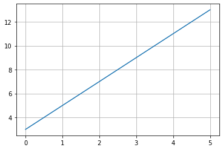

```c
//Python code to draw f(x) = 3 + 2x
pl.plot(list(range(n)),[3 + i * 2 for i in range(n)])
pl.grid()
```

### Arithmatic sequence

- linear function will generate an [arithmatic sequence](https://www.mathsisfun.com/algebra/sequences-sums-arithmetic.html)
  - f(x) = a + x * d where a is the first item, and d is the difference
- In an Arithmetic Sequence the difference between one term and the next is a constant.
- In an Arithmetic Sequence each term is found by adding the previous term by a constant.
- Example: 4, 7, 10, 13, 16, 19, 22, 25, ...

```c
//4, 7, 10, 13, 16, 19, 22, 25 ...
//f(x) =  4 + 3x is a line -> arithmatic sequence
#include <stdio.h>
int main(){
    int i, n = 10;
    int y;
    for (i = 0; i < n;i ++){
        y = i * 3 + 4; //f(x) = i * 3 + 4
        printf("%d ", y);
    }
    return 0;
}
```

```
4 7 10 13 16 19 22 25 28 31
```

```
4 7 10 13 16 19 22 25 28 31
```

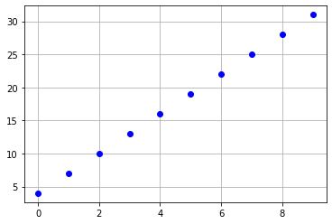

```c
#python
for i in range(10):
    print(i * 3 + 4, end= " " ) # arithmatic sequence
pl.plot(list(range(10)),[i * 3 + 4 for i in range(10)],'bo')
pl.grid()
```

```c
//How about 1, 4, 7, 10, 13, 16, 19, 22,
```

[output not shown]

## Geometric sequence

In a [Geometric Sequence](https://www.mathsisfun.com/algebra/sequences-sums-geometric.html), each term is found by multiplying the previous term by a constant.

- f(x) = $a * r ^ x$
  - a is the first term, and
  - r is the factor between the terms (called the "common ratio")
- Example: 1,2,4,8,...

```c
#include <stdio.h>
#include <math.h>
int main(){
    int i, n = 10;
    int y;
    for (i = 0; i < n; i ++){
        y = pow(2, i); //f(x) = 2 ** i
        printf("%d ", y);
    }
    return 0;
}
```

```
1 2 4 8 16 32 64 128 256 512
```

```
1, 2, 4, 8, 16, 32, 64, 128, 256, 512,
```

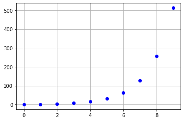

```c
/* python */
n = 10
for i in range(n):
    var =  2 ** i
    print(var, end=", ")
pl.plot(list(range(10)),[2 ** i for i in range(10)],'bo')
pl.grid()
```

## Alternating sequence

An alternating sequence is where the terms alternate between positive and negative.

- Alternating function: $y = f(x) *(−1)^𝑥$
- Example: -2,4,-6,8,-10,12..

```c
//Step1. Generating 2,4,6,8,10,....
#include <stdio.h>
#include <math.h>
int main(){
    int i, n = 10;
    int y;
    for (i = 0; i < n; i ++){
        y = (2 * i + 2) ;
        printf("%d ", y);
    }
    return 0;
}
```

```
2 4 6 8 10 12 14 16 18 20
```

```c
//Step2. adding sign
#include <stdio.h>
#include <math.h>
int main(){
    int i, n = 10;
    int y;
    for (i = 0; i < n; i ++){
        y = (2 * i + 2) * pow(-1, i + 1); //f(x) = (2 * i + 2)* (-1) ^(i+1)
        printf("%d ", y);
    }
    return 0;
}
```

```
-2 4 -6 8 -10 12 -14 16 -18 20
```

```
-2, 4, -6, 8, -10, 12, -14, 16,
```

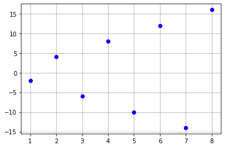

```c
# python
#Alternating pattern
#
n = 8
for i in range(1,n + 1):   #?range(n)
    var = 2 * i * (-1) ** i
    print(var, end=", ")
pl.plot(list(range(1,n+1)),[2 * i * (-1) ** i for i in range(1, n+1)],'bo')
pl.grid()
```

## Repeating sequence (%)

- 𝑦=𝑓(𝑥 𝑚𝑜𝑑 𝑝)
- Example: 3 6 3 6 3 6 3…

```c
//Repeating pattern 0, 1, 0, 1, 0, 1
#include <stdio.h>
int main(){
    int i, n = 10;
    int y;
    for (i = 0; i < n; i ++){
        y = i % 2 ;
        printf("%d ", y);
    }
    return 0;
}
```

```
0 1 0 1 0 1 0 1 0 1
```

```
0 1 0 1 0 1 0 1 0 1
```

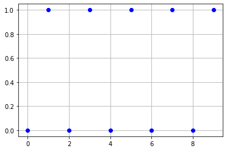

```c
#python # repeating pattern
for i in range(10):
    print(i % 2, end= " " )
pl.plot(list(range(10)),[i % 2 for i in range(10)],'bo')
pl.grid()
```

```c
//Treat 3, 6 as arithmatic patthen, let (i%2) as x plug into the arithmatic pattern
#include <stdio.h>
int main(){
    int i, n = 10;
    int y;
    for (i = 0; i < n; i ++){
        y = 3* (i % 2) + 3;
        printf("%d ", y);
    }
    return 0;
}
```

```
3 6 3 6 3 6 3 6 3 6
```

```c
//How about 2,4,6,2,4,6,
#include <stdio.h>
int main(){
    int i, n = 10;
    int y;
    for (i = 0; i < n; i ++){
        y = (i % 3) * 2 + 2;
        printf("%d, ", y);
    }
    return 0;
}
```

```
2, 4, 6, 2, 4, 6, 2, 4, 6, 2,
```

## Stepping sequence (/)

- 𝑦=𝑓(𝑥 / 𝑝)
- p represents the number of repeating terms
- Example: 2 2 4 4 6 6 …

```c
//Stepping pattern 0,0,1,1,2,2,3,3,....
#include <stdio.h>
int main(){
    int i, n = 10;
    int y;
    for (i = 0; i < n; i ++){
        y = i / 2 ;
        printf("%d ", y);
    }

    return 0;
}
```

```
0 0 1 1 2 2 3 3 4 4
```

```
0 0 1 1 2 2 3 3 4 4
```

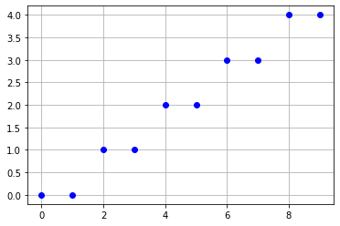

```c
#python ex2 3a
for i in range(10):
    print(i // 2, end= " " )  #
pl.plot(list(range(10)),[i // 2 for i in range(10)],'bo')
pl.grid()
```

```c
//2 2 4 4 6 6 …
//Treat 2, 4 as arithmatic patthen, let (i%2) as x plug into the arithmatic pattern
#include <stdio.h>
int main(){
    int i, n = 10;
    int y;
    for (i = 0; i < n; i ++){
        y = (i / 2) * 2 + 2 ;
        printf("%d ", y);
    }
    return 0;
}
```

```
2 2 4 4 6 6 8 8 10 10
```

```c
#include <stdio.h>
int main(){
    int i, n = 10;
    int y;
    for (i = 0; i < n; i ++){
        y = (i / 2) * 2 + 1 ;
        printf("%d ", y);
    }
    return 0;
}
```

```
1 1 3 3 5 5 7 7 9 9
```

```c
//How about  2 4 4 6 6 8 8 10 10
//(i+1) will shift one item
#include <stdio.h>
int main(){
    int i, n = 10;
    int y;
    for (i = 0; i < n; i ++){
        y = ((i+1) / 2) * 2 + 2 ;
        printf("%d ", y);
    }
    return 0;
}
```

```
2 4 4 6 6 8 8 10 10 12
```

## parabolic pattern

- f(x) = $a * x ^ b$
- b is a constant
- Example:0, 1, 4, 9, 16, 25, 36

```c
#include <stdio.h>
#include <math.h>
int main(){
    int i, n = 10;
    int y;
    for (i = 0; i < n; i ++){
        y = pow(i, 2) ;
        printf("%d ", y);
    }
    return 0;
}
```

```
0 1 4 9 16 25 36 49 64 81
```

```
81 64 49 36 25 16 9 4 1 0 1 4 9 16 25 36 49 64 81
```

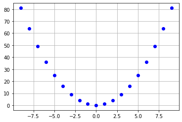

```c
#python ex2 6. parabolic pattern
for i in range(-9, 10):
    print( i ** 2, end=" ")
pl.plot(list(range(-9, 10)),[i ** 2 for i in range(-9,10)],'bo')
pl.grid()
```

back to top

## FRACTIONAL PATTERNS

Example: $\frac{1}{2}, \frac{3}{4},\frac{5}{8},\frac{7}{16},\frac{9}{32} ... $

- Find a separate pattern for the numerators and denominators
- Make sure to use the same loop for both patterns
- $\frac{1}{2}, \frac{3}{4},\frac{5}{8} \neq \frac{1 + 3 + 5}{2 + 4 + 8}$

```c
#include <stdio.h>
#include <math.h>
int main(){
    int i, n = 6;
    int denom, numer;
    float fraction;
    for (i = 0; i < n; i ++){
        numer = 2 * i + 1 ;
        denom = pow(2, i+1);
        printf("%d/%d, ", numer,denom);
        fraction = (float)numer/denom;
        printf("fraction: %.3f\n",fraction);
    }
    return 0;
}
```

```
1/2, fraction: 0.500
3/4, fraction: 0.750
5/8, fraction: 0.625
7/16, fraction: 0.438
9/32, fraction: 0.281
11/64, fraction: 0.172
```

back to top

## 4.3 [Fibonacci sequence](https://www.youtube.com/watch?v=ZC-d4dKTyKw)

```c
//Fibonacci sequence
//0 1 1 2 3 5 8 13 21 34 55 89
// Each number in the sequence is the sum of the two numbers that precede it
#include <stdio.h>
int main(){
    int i, n = 10;
    int y;
    int pre0 = 0;
    int pre1 = 1;
    printf("%d %d ", pre0, pre1);
    for (i = 0; i < n; i ++){
        y = pre0 + pre1;
        printf("%d ", y);
        pre0 = pre1;
        pre1 = y;
       }
    return 0;
}
```

```
0 1 1 2 3 5 8 13 21 34 55 89
```

back to top